# Factors that Influence the Use of Bike-Sharing Programs

Rachel Bellflowers

May 5, 2020

# 1 Introduction

Bike-sharing programs allow individuals to rent a bike at one location and then leave it at another location. Often found in cities, these programs help citizens avoid traffic and travel around quicker than walking. With over 500 bike-sharing programs in existence, it is clear that this model has gained traction. Given that these bicycles have tracking software that records who is riding, for how long, and their final destination, data about the use of such programs is easily available.

Data from the Capital Bikeshare system in Washington, D.C. were used to determine what factors contribute to higher usage of rental bikes on a daily basis in the years 2011 and 2012. Started in 2008, the Capital Bikeshare program has over 500 stations spanned across the nation’s capital, Virginia, and Maryland.

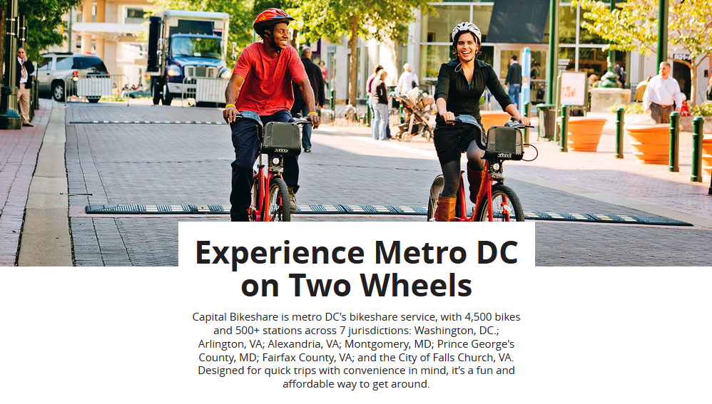

# 2 Method

## 2.1 Data Collection

This dataset was downloaded from the [UCI Machine Learning Repository](https://archive.ics.uci.edu/ml/datasets/Bike+Sharing+Dataset). The uploader of this dataset retrieved the bicycle data from [Capital Bikeshare’s website data](https://www.capitalbikeshare.com/system-data), the weather data from [i-weather.com](https://i-weather.com/), and data about holidays from the [DC Department of Human Resources](https://dchr.dc.gov/page/holiday-schedules). All data were selected for the years 2011-2012. Further information is included in the researchers’ article *Event Labeling Combining Ensemble Detectors and Background Knowledge*, Fanaee-T and Gama (2014).

## 2.3 Statistical Modeling

After trying two linear models (10-fold with cross-validation and 10-fold with cross-validation repeated 5 times) and three random tree models (10-fold cross-validation, 10-fold cross-validation repeated 5 times, and a model with bootstrapping), I found that the model with the lowest $RMSE$ and the highest $R^2$ was the 10-fold random forest model with 5 repetitions of cross-validation. The $RMSE$ for this model’s predictions on the test set was 651.6911, and the $R^2$ was 0.8924. I removed the variables for the count of casual users (`casual`) and the count of registered users (`registered`) as I was only interested in examining the count of total rental bikes (`cnt`). Additionally, I removed the date column `dteday` as it increased the RMSE.

## 2.4 Reproducibility

All code used is included in the attached `writeup.Rmd` file. The R function `set.seed()` was used to ensure the reproducibility of the models and the partitioning of the original dataset. Additionally, links to the data sources are included in the “Data Collection” section of this report. Users will need the latest version of the `R` data analysis software, the `RStudio` GUI, and the following `R` packages installed on their computer: `corrplot`, Wei and Simko (2017); `caret`, Kuhn (2020); `dplyr`, Wickham, François, et al. (2020); `ggplot2`, Wickham, Chang, et al. (2020); `magrittr`, Bache and Wickham (2014); and `yardstick`, Kuhn and Vaughan (2020).

# 3 Results

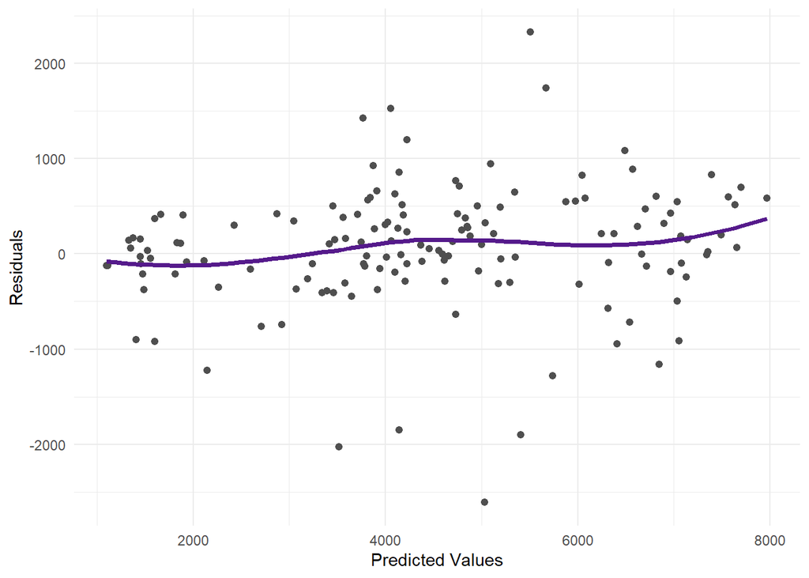

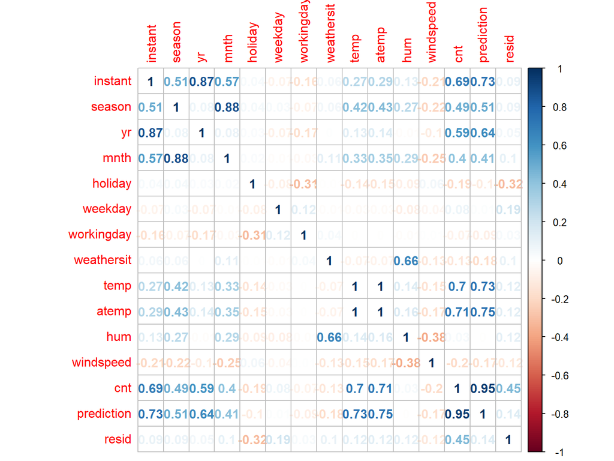

# 4 Conclusion

The results of this analysis provide some explanation for the difference in use of rental bikes in the Capital Bikeshare system over time. Interestingly, it seems that there is no significant difference for the number of bikes rented on different weekdays or whether it is a working day. I had predicted that people would be more likely to ride on weekdays when people need to travel to work.

It would be interesting to see how well this model predicts data from programs in other locations with different climates and other public transport infrastructure.

# References

Bache, Stefan Milton, and Hadley Wickham. 2014. *Magrittr: A Forward-Pipe Operator for R*. https://CRAN.R-project.org/package=magrittr.

Fanaee-T, Hadi, and Joao Gama. 2014. “Event Labeling Combining Ensemble Detectors and Background Knowledge.” *Progress in Artificial Intelligence* 2 (2): 113–27. https://doi.org/10.1007/s13748-013-0040-3.

Kuhn, Max. 2020. *Caret: Classification and Regression Training*. https://CRAN.R-project.org/package=caret.

Kuhn, Max, and Davis Vaughan. 2020. *Yardstick: Tidy Characterizations of Model Performance*. https://CRAN.R-project.org/package=yardstick.

Wei, Taiyun, and Viliam Simko. 2017. *Corrplot: Visualization of a Correlation Matrix*. https://CRAN.R-project.org/package=corrplot.

Wickham, Hadley, Winston Chang, Lionel Henry, Thomas Lin Pedersen, Kohske Takahashi, Claus Wilke, Kara Woo, Hiroaki Yutani, and Dewey Dunnington. 2020. *Ggplot2: Create Elegant Data Visualisations Using the Grammar of Graphics*. https://CRAN.R-project.org/package=ggplot2.

Wickham, Hadley, Romain François, Lionel Henry, and Kirill Müller. 2020. *Dplyr: A Grammar of Data Manipulation*. https://CRAN.R-project.org/package=dplyr.